# SMS Spam ham classifier

Shobhit Tiwari

January 14, 2018

## Synopsis

In this project we will classify sms into spam and ham using naive bayes classifier. We will use sms spam data from kaggle dataset(Spam Text Message Classification) to train the classifier.

## Data

We will download and load data in a dataframe from https://www.kaggle.com/team-ai/spam-text-message-classification/data

```r
set.seed(1222)
data <- read.csv('data.csv',stringsAsFactors = FALSE, header = TRUE)
data <- data[sample(nrow(data)),]
names(data)
```

```
## [1] "Category" "Message"
```

Now lets build a corpus of the messages using quanteda package for the text field and attach the labels as doc vars.

```r
data.corpus <- corpus(data$Message)
docvars(data.corpus, "Category") <- data$Category
```

We will subset corpus for spam and ham and create dfm for both sets.

```r
spam.dfm <- dfm(corpus_subset(data.corpus, Category == "spam"), tolower = TRUE, remove_numbers = TRUE,  remove = stopwords("SMART"),stem = TRUE, remove_punct = TRUE)

ham.dfm <- dfm(corpus_subset(data.corpus, Category == "ham"),tolower =  TRUE , remove_numbers = TRUE,   remove = stopwords("SMART"),stem = TRUE, remove_punct = TRUE)
```

Lets see the wordclod for both these to explore most frequent words in both

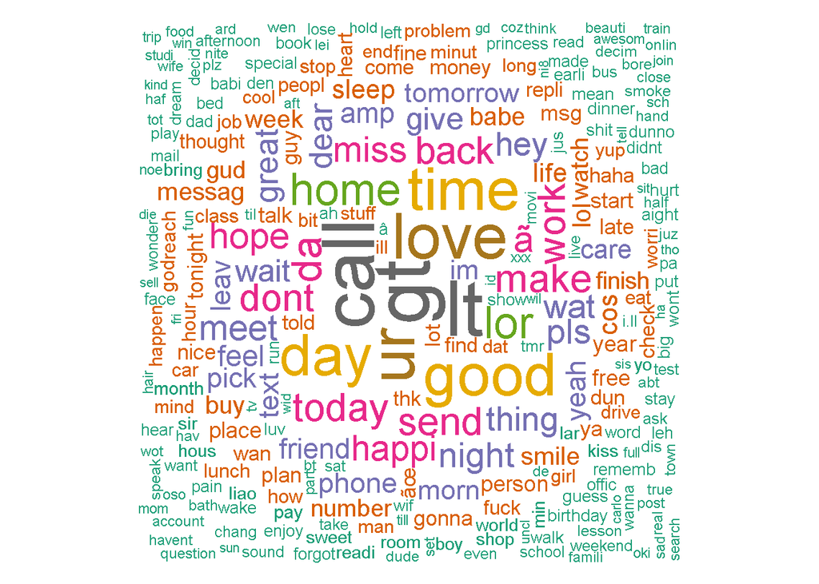

```r
textplot_wordcloud(ham.dfm, min.freq = 16, random.order = FALSE,
                   rot.per = .25,
                   colors = RColorBrewer::brewer.pal(8,"Dark2"))
```

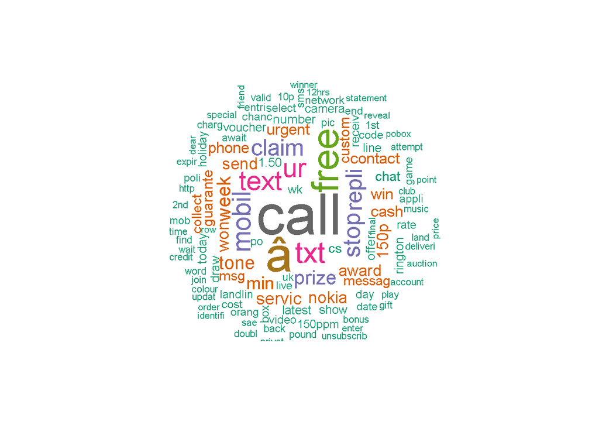

```r
textplot_wordcloud(spam.dfm, min.freq = 16, random.order = FALSE,
                   rot.per = .25,
                   colors = RColorBrewer::brewer.pal(8,"Dark2"))
```

We can see that in spam set most frequest words are call, free , prize etc which is typical of spams. And most frequent words in ham dataset is call, good, love etc.

Now we will partition the sms data into training and test sets.

```r
data.dfm <- dfm(data.corpus, tolower= TRUE)
data.dfm <- dfm_trim(data.dfm, min_count = 4, min_docfreq = 3)
data.dfm <- dfm_weight(data.dfm, type = "tfidf")

data.train <- data[1:4738,]
data.test <- data[4739:nrow(data),]

data.dfm.train <- data.dfm[1:4738,]
data.dfm.test <- data.dfm[4739:nrow(data),]
```

We will now traing our model using naive bais classification

```r
set.seed(12334)
data.model <- textmodel_nb(data.dfm.train, data.train$Category)
data.prediction <-  predict(data.model, newdata = data.dfm.test)
table(data.prediction$nb.predicted, data.test$Category)
```

```
##
##        ham spam
##   ham  705    6
##   spam  12  111
```

So the model is predicting 99 % ham messages correctly. And the model is predicting 90 % spam messages correctly.

## Conclusion

So we can see that text analysis can be done using quanteda package pretty easily with surprisingly good results.